# Documentation

*Yanis Schärer, 21.08.2023*

This documentation is intended to give an overview of the project structure and the most important classes and functions. For a more detailed description of the code, please refer to the docstrings in the code itself.

**Table of contents:**

- `misc`
- `Data`
- `Utility functions`
- `DRDataset`
- `Models`
- `Training`
- `TensorboardReader`
- `Visualization`

```python
import os
import sys
sys.path.append(os.path.abspath('../'))
sys.path.append(os.path.abspath('../source'))
sys.path.append(os.path.abspath('../data'))

import matplotlib.pyplot as plt
import torch as th
```

## misc

The training of the model requires a lot of computational resources. Thus, most of the tasks will be run on a cluster, such as ubelix (https://hpc-unibe-ch.github.io/). The `misc` folder provides bash file examples to run jobs. Feel free to customize and adapt them to your needs. Run the files in the following order:

```
sbatch job_single.sh
sbatch --dependency=afterok:<jobid> job_multi.sh
```

where `<jobid>` is the job id of the first job. The `--dependency=afterok:<jobid>` ensures that the second job is only started after the first job has finished successfully.

> **Important:** Enter a valid e-mail address to the bash files!

## Data

The images can be found in `data/images/` and the CSV-files for the various subsets are located in `data/set/`.

> `data/images` contains all images that were available at the start of the project, that is also the low quality ones. But don't worry; these images are not part of the CSV-files and are, therefore, never loaded.

## Utility Functions

Multiple functions are housed within the file `utils/util_functions.py`. Among these, `load_backbone()`, `load_datasets()`, and the transformation functions play integral roles in both the training and evaluation setups, while the function `evaluation()` serves the purpose of model assessment. These functions are employed in the tasks, where they are required, below.

```python
from utils.util_functions import load_backbone, load_datasets, test_transform, evaluation
```

## DRDataset

The DRDataset is a custom PyTorch dataset. It is located under `utils/DRDataset.py`.

> The best way to import the train and validation/test sets is through `load_datasets()`.

```python
from utils.DRDataset import DRDataset
```

```python
example_set = DRDataset(img_path='../data/images', csv_file='../data/sets/train.csv', transform=(test_transform, 128), label_transorm=None, config='both', eval=True)
idx = 33
```

```
length of the test set: 706
Example triplet: (Laterality R, Label 1)
```

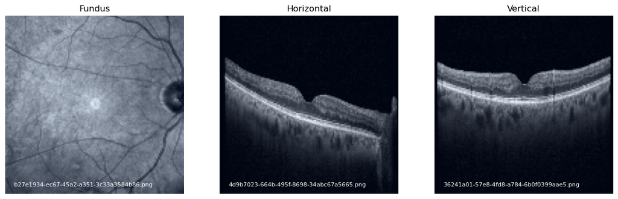

```python
print(f'length of the test set: {len(example_set)}')
example_triplet = example_set[idx]
example_triplet_names = {modality: name.split('/')[-1] for modality, name in example_set.get_item_name(idx).items()}
print(f'Example triplet: (Laterality {example_set.get_item_laterality(idx)}, Label {example_triplet["label"]})')
modalities = ['fundus', 'horizontal', 'vertical']
fig, axs = plt.subplots(1, 3, figsize=(15, 5))
for ax, m in zip(axs, modalities):
    img = example_triplet[m].permute(1, 2, 0)
    ax.set_title(m.capitalize())
    ax.axis('off')
    img = (img - img.min()) / (img.max() - img.min()) # Although the images are normalized to [0, 1] during loading, a second normalization (ImageNet) is also applied. To visualize the images correctly, we have to normalize them again.
    ax.imshow(img, vmin=0, vmax=1)
    ax.annotate(example_triplet_names[m], xy=(0.05, 0.05), xytext=(0.05, 0.05), xycoords='axes fraction', textcoords='axes fraction', ha='left', va='center', size=8, color='white')
```

```python
train_set, _, test_set = load_datasets('../data', size=128)
print(f'Length of the training set: {len(train_set)}')
print(f'Length of the test set: {len(test_set)}')
```

```
Length of the training set: 706
Length of the test set: 168
```

## Models

The models located in `utils/Models.py` are custom PyTorch `nn.Module` implementations. Moreover, a function to initialize the weights of the model with the Kaiming-He method is included.

> The best way to load the backbone models is `load_backbones()`.

```python
from utils.Models import SingleModalityClassifier, MultiModalityClassifier, kaiming_init
from torchvision.models import resnet18, ResNet18_Weights
```

```python
single_model = SingleModalityClassifier(feature_vector_size=256, backbone=resnet18, weights=ResNet18_Weights.IMAGENET1K_V1)
multi_model = MultiModalityClassifier(feature_vector_size=256, backbone=resnet18, weights={'fundus': None, 'horizontal': None, 'vertical': None}, stack_or_sum='stack', device=th.device('cpu'))
kaiming_init(multi_model)
```

```python
resnet18, weights = load_backbone(backbone_str='resnet18', script_type='single')
```

## Training

A dedicated script is provided at `source/training.py` to train a `SingleModalityClassifier`or a `MultiModalityClassifier`. When running the script, some required and optional arguments have to be passed. These include:

- `-t`, `--type` Type of training ('full', 'cv' or 'none'). 'none' is evaluation only mode and requires a model trained in 'full' mode. Required.
- `-b`, `--backbone` Backbone to be used ("resnet18", "resnet50" or "efficientnet"). Required.
- `-v`, `--feature_vector_size` Size of the feature vector (0 - 1280). Required.
- `-m`, `--image_method` Image modality or fusion method ("fundus", "horizontal", "vertical", "stack" or "sum"). Required.
- `-s`, `--batch_size` Batch size (1 - 64). Default: 1.
- `-i`, `--image_size` Image size (16 - 512). Default: 16.
- `-n`, `--name_suffix` Suffix for the model name. Default: "".
- `-d`, `--data_suffix` Suffix for the data CSV files ("" or "_refined"). Default: "".

Run the following code in your terminal:

```
python training.py -t full -b resnet18 -v 256 -m fundus -s 42 -i 128 -n _example
```

The training information (training loss, metrics, ...) is logged in an event file that can be read out with the `TensorboardReader` class. The model state is also saved.

## TensorboardReader

During training, an event file is created. These files are stored in a folder in `source`. An example folder is provided in `docs`. To read out the data, the `TensorboardReader` class can be utilized.

The method `info()` provides an overview of the available data. If the tag is available, the following methods can be used to get the respective data (else, the methods return `None`):

- `get_fold()`: Returns the fold number (only if training was done with `--type='cv'`, else 0 is returned).
- `get_num_params()`: Returns the number of parameters of the model.
- `get_epoch_length()`: Returns the number of batches per epoch.
- `get_learning_rate()`: Returns the learning rate per epoch.
- `get_training_time()`: Returns the training time in seconds.
- `get_training_loss(smmothing=0.)`: Returns the training loss every 10 iterations. If `smoothing` is not 0, the loss is smoothed (weighted by `smoothing`).
- `get_accuracy()`: Returns the accuracy.
- `get_roc()`: Returns the false-positive rate, the true-positive rate, and the thresholds.
- `get_auc()`: Returns the area under the curve.
- `get_precision_recall()`: Returns the precision, the recall, and the thresholds.
- `get_ap()`: Returns the average precision.
- `get_confusion_matrix()`: Returns the confusion matrix as array.

```python
from utils.TensorboardReader import TensorboardReader
```

```python
# training.py with --type=full
example_training = TensorboardReader('event_files_example/full/events.out.tfevents.1692695904.gnode15.28160.0_resnet18_256_stack_128', id='example-full')
example_training.info()
print()
# training.py with --type=none
example_inference = TensorboardReader('event_files_example/inference_only/events.out.tfevents.1692707562.MacBook-Air-2.99943.0_resnet18_256_stack_128', id='example-infernce-only')
example_inference.info()
```

[output not shown]

```python
# Examples
print(f'Training time in minutes: {round(example_training.get_training_time()/60, 1)}')
print(f'AUC: {round(example_training.get_auc(), 2)}')
print(f'Confusion matrix:\n{example_training.get_confusion_matrix()}')
```

```
Training time in minutes: 24.0
AUC: 0.84
Confusion matrix:
[[109   9]
 [ 24  26]]
```

## Visualization

To create heat maps to visualize the model's decision making process, the classes `CustomHiResCAM` and `CustomOcclusionMap` in the file `utils/Visualization.py` can be used. The target layers to be passed as argument in the initialization of `CustomHiResCAM` are:

ResNet-18 and ResNet-50:

```
target_layers=['fundus.backbone.layer4', 'horizontal.backbone.layer4', 'vertical.backbone.layer4']
```

EfficientNetV2-L:

```
target_layers=['fundus.backbone.features.8', 'horizontal.backbone.features.8', 'vertical.backbone.features.8']
```

```python
from utils.Visualization import CustomHiResCAM, CustomOcclusionMap
```

```python
# Load a trained example model
multi_model.load_state_dict(th.load('model_states_example/resnet18_256_stack_128.pt', map_location='cpu'))
```

```
<All keys matched successfully>
```

```python
hirescam = CustomHiResCAM(multi_model, target_layers=['fundus.backbone.layer4', 'horizontal.backbone.layer4', 'vertical.backbone.layer4'])
occlusion_map = CustomOcclusionMap(multi_model)
```

#### HiResCAM

```python
blends = hirescam.get_cam({k: img for k, img in example_triplet.items() if k != 'label'}, example_triplet['label'])
```

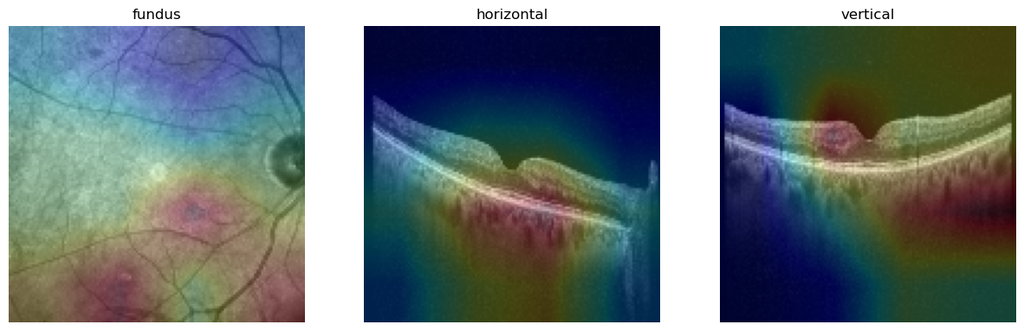

```python
fig, axs = plt.subplots(1, 3, figsize=(15, 5))
for ax, (m, blend) in zip(axs, blends.items()):
    fig, ax = hirescam.visualize(blend, fig_ax=(fig, ax))
    ax.set_title(m)
```

#### Occlusion Maps

```python
attrs = occlusion_map.get_occlusion_map({k: img for k, img in example_triplet.items() if k != 'label'}, example_triplet['label'])
```

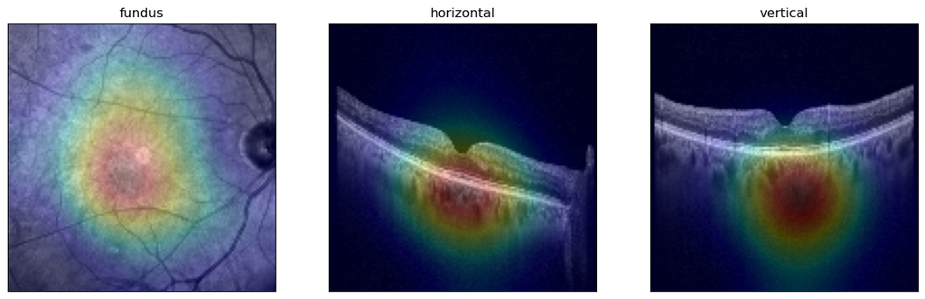

```python
fig, axs = plt.subplots(1, 3, figsize=(15, 5))
for ax, (m, attr) in zip(axs, attrs.items()):
    fig, ax = occlusion_map.visualize(attr, example_triplet[m], fig_ax=(fig, ax))
    ax.set_title(m)
```